# 830 Semester Project

# Conclusion

## Future Work

### Idea 1: Longitudinal Study of Pacing Profiles

A question of interest in regards to pace profiles is whether or not these change as a runner becomes more experienced, with the idea being that as a runner runs more races, his or her profile shifts from that having a slower half to one that is more evenly paced (if not running a faster second half). While we could try to use a proxy measure in a cross-sectional study like this (i.e., use placing in the top 10% as a measure of “ability/experience”), it could potentially be more informative to study the pacing profiles of a cohort of runners as they run their first, second, …, etc races.

Difficulties in performing such a study include:

1. First-time marathoners differ in their running histories (example: a former collegiate runner might run with a more even pacing profile than someone who picked up running recently with the sole focus of completing the distance).
2. It’s highly unlikely that a large group of people will run the same sequence of races, or even the same number of races in a given window of time.
3. Acquiring the data is time consuming, and its not always possible to get the intermediate split times for past races (for example, the author was only able to acquire intermediate split times for 7 of the 10 marathons he’s run).

### Idea 2: Pacing Profiles of Other Distances (Notably: Half Marathon)

Another question of interest is how do pacing profiles of half marathon runners vary across age, gender, and experience? While only half the distance of a marathon, the half marathon is still long enough to require an informed pacing strategy to avoid hitting the proverbial wall. Along with the difficulties encountered in the above analyses of the full mararhon datasets, half marathons add the additional challenge in that not only do the intermediate splits differ across races, it’s unusal to see a split at the half-way point (the author was unable to find any results of his that included a “quarter-marathon” split; most had some combination of 5km/10km/10mile).

It might also be interesting to compare pacing profiles for individuals who run both half and full marathons. It would be challenging to acquire this dataset, and additional confounders might impact any such analysis (for example, someone training for a full marathon might include a half-marathon in their training, but might race it more conservatively than if the half-marathon had been their goal race).

# Appendix

## Second Half over First Half Pace By Year in the Boston Marathon Data

As a quick check to see if pacing profiles varied by year in the Boston Marathon data, I computed the pace for the first and second half of the race for each individual, and the ratio of the two (second over the first). While the historgram of the ratios look similar across all three years, note that the average in 2015 is less than both 2016 and 2017. A simple one-way ANOVA test indicates that the average ratio is not the same across all three years, and it would appear that this result is driven by the lower values seen in 2015.

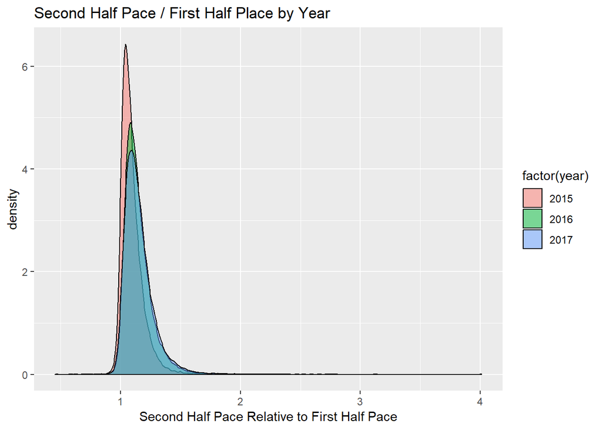

| term | df | sumsq | meansq | statistic | p.value |
| --- | --- | --- | --- | --- | --- |
| factor(year) | 2 | 54.95768 | 27.4788412 | 2091.768 | 0 |
| Residuals | 79573 | 1045.32319 | 0.0131367 | NA | NA |

| term | estimate | std.error | statistic | p.value |
| --- | --- | --- | --- | --- |
| (Intercept) | 1.0941802 | 0.0007031 | 1556.11690 | 0 |
| factor(year)2016 | 0.0516191 | 0.0009940 | 51.93076 | 0 |
| factor(year)2017 | 0.0591055 | 0.0009961 | 59.33890 | 0 |